# Individual3JL

Julia Lundstrum

3/4/2021

## Lab 3

### Part 1

```r
library(tidyverse)
```

```r
library(readxl)
library(ggplot2)
library(dplyr)
df <- readxl::read_xls('./GSS.xls')
df
```

```
## # A tibble: 64,816 x 9
##    `Gss year for t… `Respondent id … `Number of hour… `Marital status`
##               <dbl>            <dbl> <chr>            <chr>
##  1             1972                1 Not applicable   Never married
##  2             1972                2 Not applicable   Married
##  3             1972                3 Not applicable   Married
##  4             1972                4 Not applicable   Married
##  5             1972                5 Not applicable   Married
##  6             1972                6 Not applicable   Never married
##  7             1972                7 Not applicable   Divorced
##  8             1972                8 Not applicable   Never married
##  9             1972                9 Not applicable   Never married
## 10             1972               10 Not applicable   Married
## # … with 64,806 more rows, and 5 more variables: `Highest year of school
## #   completed` <chr>, `Political party affiliation` <chr>, `Belief in life
## #   after death` <chr>, `General happiness` <chr>, `Ballot used for
## #   interview` <chr>
```

### Part 2

#### Question 1

```r
names(df) <- str_replace_all(names(df), c(" " = "_"))
df$Highest_year_of_school_completed <- as.numeric(as.character(df$Highest_year_of_school_completed))
df$Marital_status <- factor(df$Marital_status, levels = c("No answer", "Never married", "Divorced","Married","Separated", "Widowed"))
ms <- df %>%
  group_by(Marital_status) %>%
  summarize(
    mean_rate = mean(Highest_year_of_school_completed, na.rm=TRUE)
  )
ms
```

```
## # A tibble: 7 x 2
##   Marital_status mean_rate
## * <fct>              <dbl>
## 1 No answer           15.5
## 2 Never married       13.4
## 3 Divorced            13.1
## 4 Married             13.0
## 5 Separated           11.9
## 6 Widowed             11.2
## 7 <NA>               NaN
```

Disregarding no answers, those who have never been married had completed the most education followed by those who had been divorced. Widows had the least number of years of education completed in this data set.

#### Question 2

```r
be <- df %>%
  group_by(Marital_status) %>%
  filter(Highest_year_of_school_completed > mean(Highest_year_of_school_completed, na.rm=TRUE)) %>%
  ungroup()
str(be)
```

```
## tibble [30,714 × 9] (S3: tbl_df/tbl/data.frame)
##  $ Gss_year_for_this_respondent    : num [1:30714] 1972 1972 1972 1972 1972 ...
##  $ Respondent_id_number            : num [1:30714] 1 4 6 8 11 16 17 19 20 23 ...
##  $ Number_of_hours_worked_last_week: chr [1:30714] "Not applicable" "Not applicable" "Not applicable" "Not applicable" ...
##  $ Marital_status                  : Factor w/ 6 levels "No answer","Never married",..: 2 4 2 2 4 4 4 4 2 4 ...
##  $ Highest_year_of_school_completed: num [1:30714] 16 17 14 16 13 14 14 17 14 13 ...
##  $ Political_party_affiliation     : chr [1:30714] "Ind,near dem" "Not str democrat" "Ind,near dem" "Ind,near dem" ...
##  $ Belief_in_life_after_death      : chr [1:30714] "Not applicable" "Not applicable" "Not applicable" "Not applicable" ...
##  $ General_happiness               : chr [1:30714] "Not too happy" "Not too happy" "Pretty happy" "Not too happy" ...
##  $ Ballot_used_for_interview       : chr [1:30714] "Not applicable" "Not applicable" "Not applicable" "Not applicable" ...
```

#### Question 3

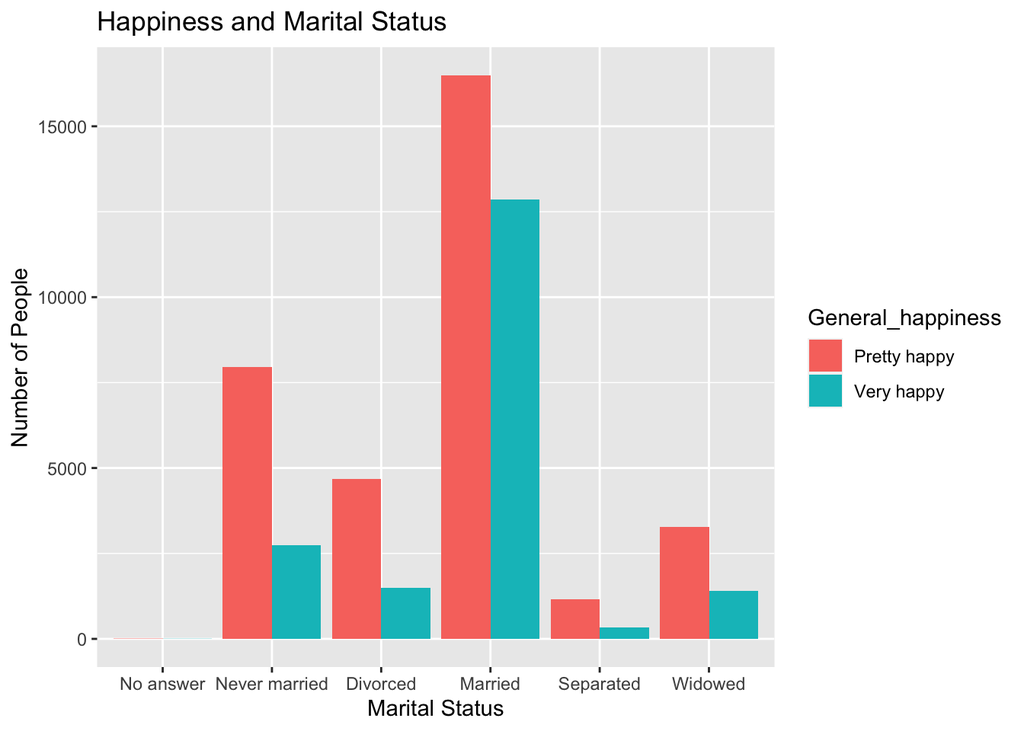

```r
happy <- df %>% filter(General_happiness == "Very happy" | General_happiness == "Pretty happy")
ggplot(happy, aes(Marital_status, fill =General_happiness)) + geom_bar(position = "dodge")  + ggtitle("Happiness and Marital Status") + ylab("Number of People") + xlab("Marital Status")
```

```r
happy %>% count(Marital_status)
```

```
## # A tibble: 6 x 2
##   Marital_status     n
## * <fct>          <int>
## 1 No answer         16
## 2 Never married  10686
## 3 Divorced        6180
## 4 Married        29342
## 5 Separated       1487
## 6 Widowed         4675
```

The most people who answered that they were pretty happy or very happy are married, followed by those who have never been married. Those who were happy were least likely to be separated, disregarding the no answer responses.

#### Question 4

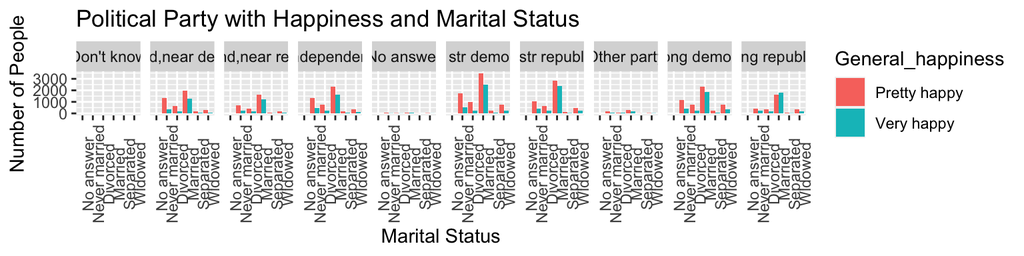

```r
pa <- happy %>% group_by(Political_party_affiliation)
ggplot(pa, aes(Marital_status, fill = General_happiness)) + geom_bar(position = "dodge") + facet_grid(cols = vars(Political_party_affiliation)) + theme(axis.text.x = element_text(angle = 90)) + ggtitle("Political Party with Happiness and Marital Status") + ylab("Number of People") + xlab("Marital Status")
```

```r
pa %>% count(Marital_status)
```

```
## # A tibble: 56 x 3
## # Groups:   Political_party_affiliation [10]
##    Political_party_affiliation Marital_status     n
##    <chr>                       <fct>          <int>
##  1 Don't know                  Never married      1
##  2 Don't know                  Married            6
##  3 Don't know                  Widowed            1
##  4 Ind,near dem                No answer          1
##  5 Ind,near dem                Never married   1670
##  6 Ind,near dem                Divorced         803
##  7 Ind,near dem                Married         3203
##  8 Ind,near dem                Separated        193
##  9 Ind,near dem                Widowed          378
## 10 Ind,near rep                Never married    983
## # … with 46 more rows
```

There does not appear to be a strong difference between happiness and marital status by political party. It does seem like Democrats’ marital status are a bit more uniform than the Republicans who answered.

#### Question 5

```r
ms
```

```
## # A tibble: 7 x 2
##   Marital_status mean_rate
## * <fct>              <dbl>
## 1 No answer           15.5
## 2 Never married       13.4
## 3 Divorced            13.1
## 4 Married             13.0
## 5 Separated           11.9
## 6 Widowed             11.2
## 7 <NA>               NaN
```

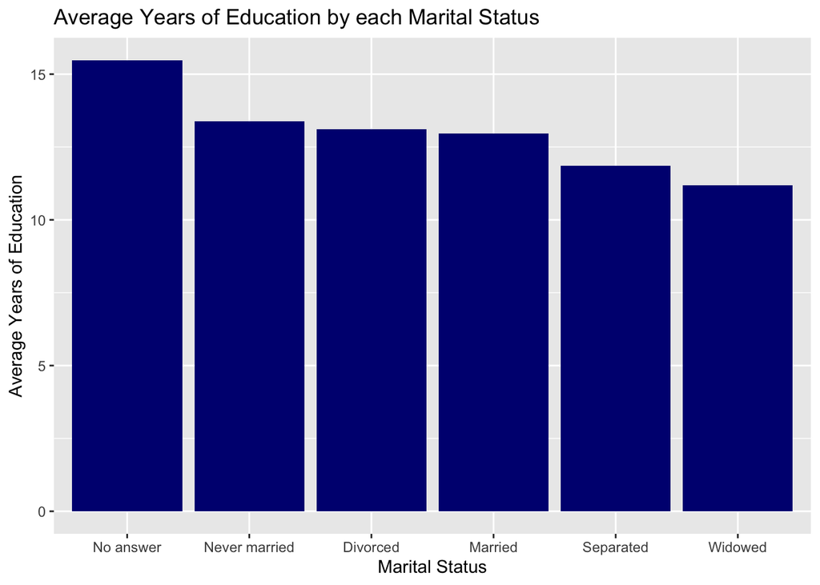

```r
ggplot(subset(ms, !is.na(Marital_status)), aes(x=Marital_status, weight=mean_rate)) + geom_bar(fill = "Navy") + ggtitle("Average Years of Education by each Marital Status") + ylab("Average Years of Education") + xlab("Marital Status")
```

The appears to be a moderate correlation between marital status and number of years of education. There are a variety of reasons that could account for this correlation and correlation does not necessary mean causation. Those with less responsibilities might have more time to complete higher education.

#### Question 6

First question I want to explore: How does number of hours worked impact party affiliation?

```r
df$Number_of_hours_worked_last_week <- as.numeric(as.character(df$Number_of_hours_worked_last_week))
hr <- df %>%
  group_by(Political_party_affiliation) %>%
  summarize(
    mean_rate = mean(Number_of_hours_worked_last_week, na.rm=TRUE)
  )
hr
```

```
## # A tibble: 11 x 2
##    Political_party_affiliation mean_rate
##  * <chr>                           <dbl>
##  1 Don't know                       40.8
##  2 Ind,near dem                     40.7
##  3 Ind,near rep                     42.4
##  4 Independent                      41.0
##  5 No answer                        40.4
##  6 Not str democrat                 41.0
##  7 Not str republican               42.0
##  8 Other party                      42.0
##  9 Strong democrat                  40.5
## 10 Strong republican                42.2
## 11 <NA>                            NaN
```

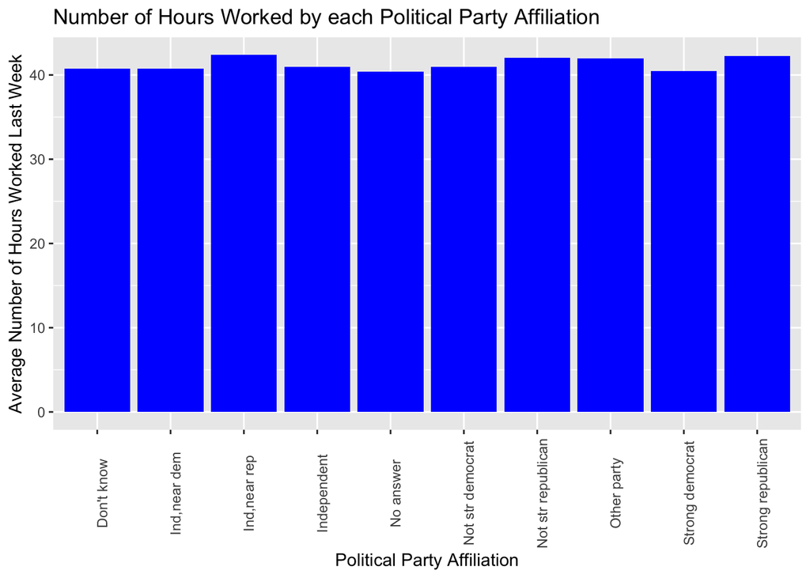

```r
ggplot(subset(hr, !is.na(Political_party_affiliation)), aes(x=Political_party_affiliation, weight=mean_rate)) + geom_bar(fill = "Blue") + theme(axis.text.x = element_text(angle = 90)) + ggtitle("Number of Hours Worked by each Political Party Affiliation") + ylab("Average Number of Hours Worked Last Week") + xlab("Political Party Affiliation")
```

There does not appear to be a significant correlation between the number of hours worked last week and political party affiliation.

Second question I want to explore: How does highest year of education completed impact party affiliation?

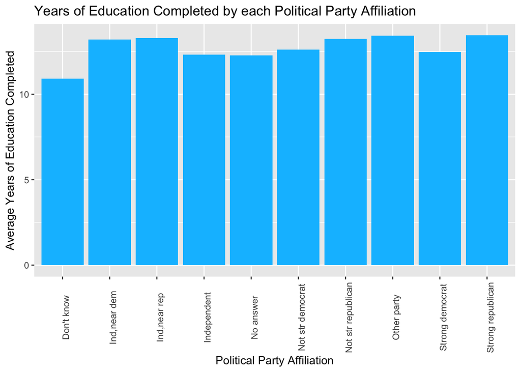

```r
ed <- df %>%
  group_by(Political_party_affiliation) %>%
  summarize(
    mean_rate = mean(Highest_year_of_school_completed, na.rm=TRUE)
  )
ggplot(subset(ed, !is.na(Political_party_affiliation)), aes(x=Political_party_affiliation, weight=mean_rate)) + geom_bar(fill = "deepskyblue") + theme(axis.text.x = element_text(angle = 90)) + ggtitle("Years of Education Completed by each Political Party Affiliation") + ylab("Average Years of Education Completed") + xlab("Political Party Affiliation")
```

There does not appear to be a significant correlation between the years of education completed and political party affiliation.